# 0717_잎 모양에 영향을 미치는 요인 분석

Jihye Park, Kihan Kim, Goeun Lee, Dream Park

2020 7 17

## **leafshape 데이터 불러오기**

```r
ls <- read.csv("C:/Users/LENOVO/Documents/leafshape.csv")
str(ls)
```

**output**

```
## 'data.frame':    286 obs. of  4 variables:
##  $ bladelen: num  33.9 33.3 29.4 26.9 26.7 ...
##  $ petiole : num  1.403 1.016 2.392 0.809 0.803 ...
##  $ bladewid: num  13.65 10.26 12.21 8.7 8.41 ...
##  $ arch    : int  0 0 0 0 0 0 0 0 0 0 ...
```

```r
summary(ls)
```

**output**

```
##     bladelen          petiole            bladewid           arch
##  Min.   : 0.8555   Min.   : 0.06917   Min.   : 0.145   Min.   :0.0000
##  1st Qu.:11.9250   1st Qu.: 0.57637   1st Qu.: 4.022   1st Qu.:0.0000
##  Median :16.2150   Median : 0.95061   Median : 5.610   Median :0.0000
##  Mean   :17.6497   Mean   : 2.23616   Mean   : 6.807   Mean   :0.3287
##  3rd Qu.:20.9075   3rd Qu.: 1.65651   3rd Qu.: 7.397   3rd Qu.:1.0000
##  Max.   :72.3000   Max.   :51.08000   Max.   :46.170   Max.   :1.0000
```

286행, 4개의 변수

| 종속변수 | 독립변수 |
| --- | --- |
| Arch (잎 모양) | Bladelen(잎의 길이) / Petiole(잎자루의 길이) / Bladewid(잎의 넓이) |

0: 아치형- 숙인 잎 모양/ 1: 직립성- 곧은 잎 모양

#### **boxplot 통해 이상치 확인**

```r
par(mfrow=c(2,2))
boxplot(ls$bladelen, main='Bladelen')
boxplot(ls$petiole, main='Petiole')
boxplot(ls$bladewid, main='Bladewid')
boxplot(ls$arch, main='Arch')
```

**plot**

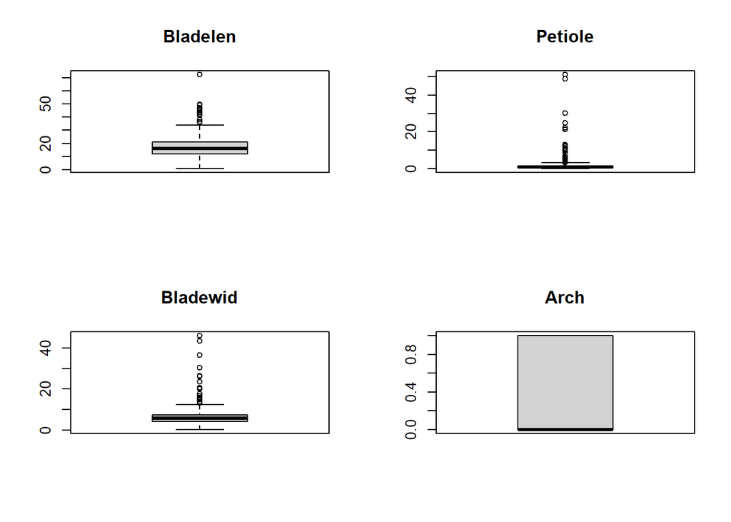

## **이상치 제거**

이상치 제거를 위해, Upper Fence 이하의 데이터만을 추출

이상치 제거 후 286개에서 238행으로 축소

#### **bladelen**

```r
l_Q1 <- quantile(ls$bladelen, probs = c(0.25), na.rm=T)
l_Q1
```

**output**

```
##    25%
## 11.925
```

```r
l_Q3 <- quantile(ls$bladelen, probs = c(0.75), na.rm=T)
l_Q3
```

**output**

```
##     75%
## 20.9075
```

```r
UC <- l_Q3 + 1.5*(l_Q3-l_Q1) # UC : Upper Fence
UC
```

**output**

```
##      75%
## 34.38125
```

```r
clear_l <- subset(ls, bladelen<UC)
```

#### **petiole**

```r
p_Q1 <- quantile(clear_l$petiole, probs = c(0.25), na.rm=T)
p_Q1
```

**output**

```
##     25%
## 0.56118
```

```r
p_Q3 <- quantile(clear_l$petiole, probs = c(0.75), na.rm=T)
p_Q3
```

**output**

```
##     75%
## 1.50984
```

```r
UC <- p_Q3 + 1.5*(p_Q3-p_Q1)
UC
```

**output**

```
##     75%
## 2.93283
```

```r
clear_p <- subset(clear_l, petiole<UC)
```

#### **bladewid**

```r
w_Q1 <- quantile(clear_p$bladewid, probs = c(0.25), na.rm=T)
w_Q1
```

**output**

```
##  25%
## 3.78
```

```r
w_Q3 <- quantile(clear_p$bladewid, probs = c(0.75), na.rm=T)
w_Q3
```

**output**

```
##  75%
## 6.62
```

```r
UC <- w_Q3 + 1.5*(w_Q3-w_Q1)
UC
```

**output**

```
##   75%
## 10.88
```

```r
clear <- subset(clear_p, bladewid<UC)
```

#### **최종 boxplot**

```r
boxplot(clear)
```

**plot**

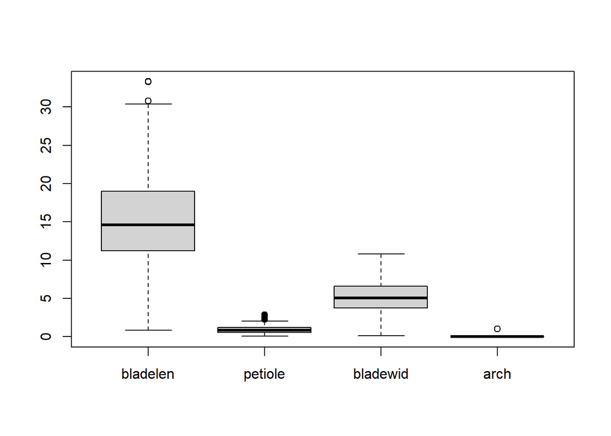

## **히스토그램**

데이터의 정규성 시각적으로 확인

```r
par(mfrow=c(2,2))
hist(clear$bladelen)
hist(clear$petiole)
hist(clear$bladewid)
hist(clear$arch)
```

**plot**

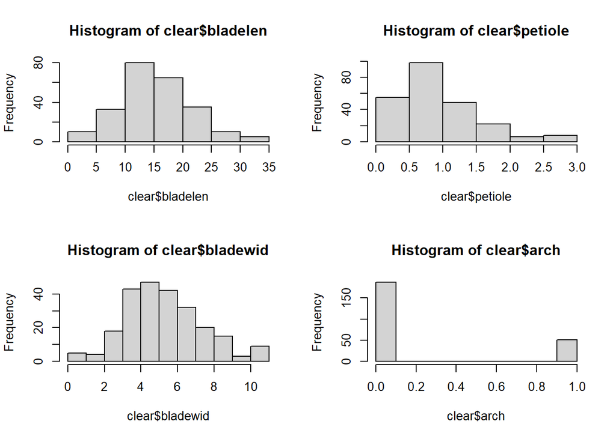

## **적합도 검정**

```r
table(clear$arch)
```

**output**

```
##
##   0   1
## 187  51
```

```r
sum(clear$arch==0)/nrow(clear)
```

**output**

```
## [1] 0.7857143
```

```r
sum(clear$arch==1)/nrow(clear)
```

**output**

```
## [1] 0.2142857
```

```r
chisq.test(table(clear$arch), p=c(0.79,0.21))
```

**output**

```
##
##  Chi-squared test for given probabilities
##
## data:  table(clear$arch)
## X-squared = 0.02635, df = 1, p-value = 0.871
```

| H0 | 그룹 간 비율에 차이가 없다. (p0=0.79, p1=0.21) |
| --- | --- |
| HA | 그룹 간 비율에 1개 이상 차이가 있다. |

- 귀무가설을 기각할 수 없으므로 분석을 하기에 적합한 데이터 모델이라고 판단

## **상관관계 분석**

종속변수, 독립변수 간 상관관계 확인

```r
# install.packages("corrgram")
library(corrgram)
corrgram(clear, upper.panel = panel.conf)
```

**plot**

[figure not shown]

## **로지스틱 회귀분석**

종속변수에 영향을 미치는 독립변수 확인

```r
library(nnet)

datanum <- nrow(clear)
datanum
```

**output**

```
## [1] 238
```

```r
train <- sample(1:datanum)<(datanum*0.8)
test <- clear[!train,]
head(test)
```

**output**

```
##    bladelen  petiole bladewid arch
## 2     33.32 1.016260    10.26    0
## 4     26.87 0.808787     8.70    0
## 5     26.67 0.802767     8.41    0
## 13    21.30 1.461180     6.59    0
## 14    20.97 1.360953     6.73    0
## 15    20.82 0.884850     6.71    0
```

```r
train <- clear[train,]
head(train)
```

**output**

```
##    bladelen  petiole bladewid arch
## 6     24.23 1.490145     7.70    0
## 7     23.85 1.092330     5.69    0
## 8     23.30 1.910600     8.41    0
## 9     23.11 1.881154     7.95    0
## 10    23.08 0.976284     6.98    0
## 12    21.57 2.622912     8.67    0
```

```r
lm <- glm(arch~.,data=train, family="binomial")
lm
```

**output**

```
##
## Call:  glm(formula = arch ~ ., family = "binomial", data = train)
##
## Coefficients:
## (Intercept)     bladelen      petiole     bladewid
##     -1.1239       0.1005       2.8356      -0.9715
##
## Degrees of Freedom: 189 Total (i.e. Null);  186 Residual
## Null Deviance:       181.5
## Residual Deviance: 136.5     AIC: 144.5
```

```r
summary(lm)
```

**output**

```
##
## Call:
## glm(formula = arch ~ ., family = "binomial", data = train)
##
## Deviance Residuals:
##     Min       1Q   Median       3Q      Max
## -1.5935  -0.5462  -0.3782  -0.1984   2.6214
##
## Coefficients:
##             Estimate Std. Error z value Pr(>|z|)
## (Intercept)  -1.1239     0.6098  -1.843   0.0653 .
## bladelen      0.1005     0.0649   1.549   0.1215
## petiole       2.8356     0.5682   4.990 6.03e-07 ***
## bladewid     -0.9715     0.2320  -4.187 2.83e-05 ***
## ---
## Signif. codes:  0 '***' 0.001 '**' 0.01 '*' 0.05 '.' 0.1 ' ' 1
##
## (Dispersion parameter for binomial family taken to be 1)
##
##     Null deviance: 181.53  on 189  degrees of freedom
## Residual deviance: 136.49  on 186  degrees of freedom
## AIC: 144.49
##
## Number of Fisher Scoring iterations: 5
```

[output not shown]

- petiole(잎자루의 길이), bladewid(잎의 넓이)의 p-value< 0.05이므로 종속변수인 잎의 모양(Arch)에 영향을 미침
- bladelen(잎의 길이)의 p-value>0.05이므로 잎의 모양(Arch)에 영향을 미치지 않음

## **변수 선택**

```r
library(mlbench)
m <- step(lm, direction="both") # 단계적 방법 선택
```

**output**

```
## Start:  AIC=144.49
## arch ~ bladelen + petiole + bladewid
##
##            Df Deviance    AIC
## <none>          136.49 144.49
## - bladelen  1   138.88 144.88
## - bladewid  1   158.85 164.85
## - petiole   1   172.45 178.45
```

```r
formula(m)
```

**output**

```
## arch ~ bladelen + petiole + bladewid
```

- 모든 독립변수를 제거하지 않은 모델의 AIC 가장 낮음 => 가장 좋은 모델
- 가장 연관성이 높은 독립변수 petiole(잎자루의 길이)을 제거한 모델의 AIC 값이 가장 큼